# Exploratory and Inferential Analysis of Compliance Behaviour Across Nigerian Tax Obligations

Author

Lilian Obadan

Published

May 9, 2026

## 1. Executive Summary

This study examines filing compliance behaviour for 104 tax filing observations across 13 companies with major Nigerian tax obligations including Value Added Tax (VAT), Pay-As-You-Earn (PAYE), Withholding Tax (WHT), and Companies Income Tax (CIT). The business problem is that companies operating within the same regulatory environment may demonstrate inconsistent filing behaviour across different tax obligations, creating delayed remittances and reconciliation challenges for the companies and their tax consultants, as well as compliance inefficiencies and potential revenue leakage to the tax authorities.

Using anonymised operational tax compliance data collected from tax returns filed on behalf of clients, this study applies five analytical techniques: Exploratory Data Analysis, Data Visualisation, Hypothesis Testing, Correlation Analysis, and Regression Analysis. The purpose is to understand whether tax compliance — measured by filing delay behaviour — differs across tax types and whether other operational variables such as filing frequency, company turnover, amount paid, industry sector, and management type are associated with compliance behaviour.

The study finds that compliance varies significantly across tax types. VAT achieves the highest level of compliance with a 100% on-time filing rate, attributable to its clear monthly filing deadlines, automatic penalties for late filing, and the high frequency of filing which builds habitual compliance behaviour. CIT records the highest average delay and the most severe individual non-compliance event (677 days), attributable to the substantial cash outlay required, the infrequent annual filing cycle, and the complexity of tax computation. A major recommendation arising from this study is the introduction of monthly filing of estimated CIT payments by all companies, similar to the practice already established in the upstream oil and gas sector.

## 2. Professional Disclosure

I work as a tax compliance professional within the tax advisory and compliance sector, where I am responsible for monitoring filing timelines, reviewing statutory obligations, supporting taxpayers, analysing compliance behaviour, and assisting companies in meeting their compliance goals. These responsibilities are directly relevant to my day-to-day work and form the operational context from which this dataset was drawn. This study is directly connected to my professional practice because it uses operational tax filing data to examine compliance behaviour across VAT, PAYE, WHT, and CIT obligations.

**Exploratory Data Analysis** is relevant because tax compliance data typically contains filing variations, outliers, and distributional patterns that must first be understood before any deeper analysis is conducted.

**Data Visualisation** is relevant because tax findings must frequently be communicated clearly to clients, management teams, and regulators who are not statisticians.

**Hypothesis Testing** is relevant because it allows me to determine whether observed differences in filing delays across tax types are statistically meaningful.

**Correlation Analysis** is relevant because filing delay behaviour may be associated with operational variables such as filing frequency, turnover, and amount paid.

**Regression Analysis** is relevant because it estimates the independent contribution of each factor to filing delay, enabling targeted, prioritised recommendations.

## 3. Data Collection & Sampling

The dataset was collected from anonymised operational tax compliance records relating to 13 selected companies and their filing behaviour across VAT, PAYE, WHT, and CIT obligations. Each observation represents a unique company–tax type–filing period combination, yielding 104 records across four filing periods from January 2024 to July 2025.

The sampling method is **purposive sampling**: data was extracted from compliance tracking registers maintained in the normal course of professional tax advisory work. All company identifiers were anonymised and replaced with codes (Company A through Company M) before analysis. No taxpayer identification numbers, personal identifiers, or confidential client details are disclosed.

```r
cat("Rows:", nrow(df), "| Columns:", ncol(df), "\n")
```

```
Rows: 104 | Columns: 14
```

```r
cat("Missing values per column:\n")
```

```
Missing values per column:
```

```r
print(colSums(is.na(df)))
```

```
           client filing_delay_days     filing_period          tax_type
                0                 0                 0                 0
 filing_frequency   industry_sector  company_turnover       amount_paid
                0                 0                 0                 0
        date_paid   management_type      turnover_ngn     amount_paid_n
                0                 0                 0                20
     revenue_band compliance_status
                0                 0
```

The 104 observations exceed the assessment minimum of 100 and support all five inferential techniques applied. The dataset is a census of available filing records for the 13 clients under active engagement during the observation period, which maximises completeness but limits generalisation to the broader Nigerian corporate taxpayer population.

## 4. Data Description

### Variable Dictionary

Table 1 — Variable Dictionary

| Variable | Type | Description |
| --- | --- | --- |
| Client | Categorical | Anonymised company code (A-M); 13 unique companies |
| Filing_Delay_Days | Numeric | Days between statutory due date and actual filing; 0 = on time |
| Filing_Period | Categorical | Tax filing period; 4 periods covered |
| Tax_Type | Categorical | Statutory obligation: VAT, PAYE, WHT, or CIT |
| Filing_Frequency | Numeric | Required filings per year: 12 monthly \| 1 annual (CIT) |
| Industry_Sector | Categorical | Industry: ICT or Oil and Gas |
| Company_Turnover | Numeric | Annual turnover in Naira |
| Amount_Paid | Numeric | Amount remitted in Naira; 20 entries are nil |
| Date_Paid | Date | Date payment was received |
| Management_Type | Categorical | Local or Foreign management |
| compliance_status | Derived | On Time vs Delayed (binary outcome) |
| revenue_band | Derived | Four turnover tiers |

### Distributional Summary

```r
df |>
  dplyr::select(filing_delay_days, turnover_ngn, amount_paid_n,
                filing_frequency, tax_type, industry_sector,
                management_type, compliance_status, revenue_band) |>
  skim()
```

Data summary

| Name | dplyr::select(…) |
| --- | --- |
| Number of rows | 104 |
| Number of columns | 9 |
| _______________________ |  |
| Column type frequency: |  |
| factor | 5 |
| numeric | 4 |
| ________________________ |  |
| Group variables | None |

**Variable type: factor**

| skim_variable | n_missing | complete_rate | ordered | n_unique | top_counts |
| --- | --- | --- | --- | --- | --- |
| tax_type | 0 | 1 | FALSE | 4 | VAT: 26, PAY: 26, WHT: 26, CIT: 26 |
| industry_sector | 0 | 1 | FALSE | 2 | Oil: 72, ICT: 32 |
| management_type | 0 | 1 | FALSE | 2 | Loc: 73, For: 31 |
| compliance_status | 0 | 1 | FALSE | 2 | On : 78, Del: 26 |
| revenue_band | 0 | 1 | FALSE | 4 | Ban: 48, Ban: 25, Ban: 22, Ban: 9 |

**Variable type: numeric**

| skim_variable | n_missing | complete_rate | mean | sd | p0 | p25 | p50 | p75 | p100 | hist |
| --- | --- | --- | --- | --- | --- | --- | --- | --- | --- | --- |
| filing_delay_days | 0 | 1.00 | 2.131000e+01 | 8.393000e+01 | 0 | 0.000000e+00 | 0 | 2.500000e-01 | 677 | ▇▁▁▁▁ |
| turnover_ngn | 0 | 1.00 | 2.666650e+10 | 2.673740e+10 | 1487384000 | 7.748103e+09 | 13053109840 | 3.498751e+10 | 99647644000 | ▇▃▁▁▁ |
| amount_paid_n | 20 | 0.81 | 3.215205e+08 | 1.023805e+09 | 1117171 | 6.019648e+06 | 14687968 | 6.285962e+07 | 7319115867 | ▇▁▁▁▁ |
| filing_frequency | 0 | 1.00 | 9.250000e+00 | 4.790000e+00 | 1 | 9.250000e+00 | 12 | 1.200000e+01 | 12 | ▂▁▁▁▇ |

### Observations by Tax Type

Table 2a — Observations by Tax Type

| Tax Type | n | % |
| --- | --- | --- |
| VAT | 26 | 25.0% |
| PAYE | 26 | 25.0% |
| WHT | 26 | 25.0% |
| CIT | 26 | 25.0% |

### Observations by Industry Sector

Table 2b — Observations by Industry Sector

| Industry | n | % |
| --- | --- | --- |
| ICT | 32 | 30.8% |
| Oil and Gas | 72 | 69.2% |

### Observations by Management Type

Table 2c — Observations by Management Type

| Management Type | n | % |
| --- | --- | --- |
| Local | 73 | 70.2% |
| Foreign | 31 | 29.8% |

### Observations by Revenue Band

Table 3 — Observations by Revenue Band

| Revenue Band | n | % |
| --- | --- | --- |
| Band 1 < N5B | 9 | 8.7% |
| Band 2 N5-15B | 48 | 46.2% |
| Band 3 N15-35B | 25 | 24.0% |
| Band 4 > N35B | 22 | 21.2% |

## 5. Exploratory Data Analysis

> **Technique 1 of 5** — Summary statistics, missing-value analysis, outlier detection

**NoteBusiness Justification**

Before any compliance recommendation can be made, the data must be examined for quality issues, distributional irregularities, and anomalies. This step mirrors the mandatory pre-engagement data review I conduct before submitting client representations to FIRS.

### 5.1 Summary Statistics

Table 4 — Descriptive Statistics: Filing_Delay_Days

| Statistic | Value |
| --- | --- |
| N | 104 |
| Mean | 21.31 |
| Median | 0 |
| Std Dev | 83.93 |
| Min | 0 |
| Q1 (25%) | 0 |
| Q3 (75%) | 0.25 |
| Max | 677 |
| % On Time (delay = 0) | 75% |
| Skewness | 5.61 |

### 5.2 Filing Delay by Tax Type

Table 5 — Filing Delay Summary by Tax Type

| Tax Type | n | Mean Delay | Median Delay | Min | Max | % On Time |
| --- | --- | --- | --- | --- | --- | --- |
| VAT | 26 | 0.00 | 0 | 0 | 0 | 100% |
| PAYE | 26 | 4.92 | 0 | 0 | 48 | 53.8% |
| WHT | 26 | 5.15 | 0 | 0 | 119 | 80.8% |
| CIT | 26 | 75.15 | 0 | 0 | 677 | 65.4% |

### 5.3 Outlier Detection

```
IQR upper fence: 0.625 | Outliers flagged: 26
```

Table 6 — Outlier Observations (IQR Method)

| client | tax_type | filing_period | filing_delay_days | revenue_band | management_type |
| --- | --- | --- | --- | --- | --- |
| Company B | CIT | 2025-06 | 677 | Band 3 N15-35B | Local |
| Company E | CIT | 2024-06 | 324 | Band 2 N5-15B | Foreign |
| Company B | CIT | 2024-06 | 312 | Band 2 N5-15B | Local |
| Company F | CIT | 2024-06 | 212 | Band 2 N5-15B | Foreign |
| Company E | CIT | 2025-06 | 170 | Band 3 N15-35B | Foreign |
| Company D | WHT | 2025-07 | 119 | Band 4 > N35B | Local |
| Company M | CIT | 2024-06 | 90 | Band 1 < N5B | Local |
| Company C | CIT | 2024-06 | 89 | Band 3 N15-35B | Local |
| Company C | CIT | 2025-06 | 70 | Band 4 > N35B | Local |
| Company D | PAYE | 2025-01 | 48 | Band 4 > N35B | Local |
| Company G | PAYE | 2025-07 | 14 | Band 3 N15-35B | Local |
| Company B | PAYE | 2025-07 | 11 | Band 2 N5-15B | Local |
| Company F | PAYE | 2025-07 | 11 | Band 2 N5-15B | Foreign |
| Company G | CIT | 2025-06 | 10 | Band 3 N15-35B | Local |
| Company M | PAYE | 2025-01 | 10 | Band 2 N5-15B | Local |
| Company E | PAYE | 2025-01 | 9 | Band 3 N15-35B | Foreign |
| Company F | PAYE | 2025-01 | 9 | Band 2 N5-15B | Foreign |
| Company J | WHT | 2025-07 | 9 | Band 2 N5-15B | Local |
| Company I | PAYE | 2025-07 | 8 | Band 3 N15-35B | Local |
| Company L | WHT | 2025-01 | 4 | Band 2 N5-15B | Foreign |
| Company L | PAYE | 2025-01 | 3 | Band 2 N5-15B | Foreign |
| Company B | PAYE | 2025-01 | 2 | Band 2 N5-15B | Local |
| Company H | PAYE | 2025-01 | 2 | Band 4 > N35B | Local |
| Company B | WHT | 2025-01 | 1 | Band 2 N5-15B | Local |
| Company C | PAYE | 2025-01 | 1 | Band 4 > N35B | Local |
| Company K | WHT | 2025-01 | 1 | Band 1 < N5B | Local |

**WarningData Quality Issues**

**Issue 3 — Extreme outlier at 677 days:** One CIT filing — a genuine compliance failure, not a data error. Retained in the analysis with appropriate acknowledgement.

## 6. Data Visualisation

> **Technique 2 of 5** — Grammar of graphics, chart selection, storytelling

### Figure 1 — Distribution of Filing Delay Days

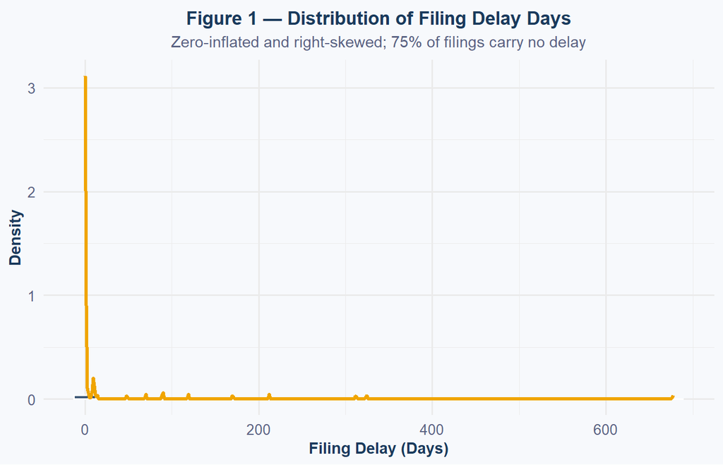

### Figure 2 — Compliance Rate by Tax Type

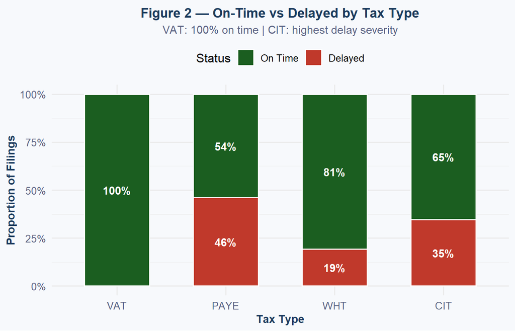

### Figure 3 — Filing Delay Distribution by Tax Type

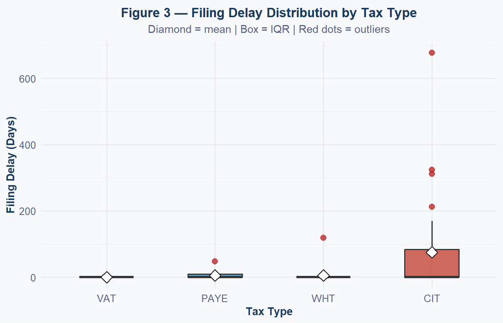

### Figure 4 — Mean Filing Delay by Revenue Band & Management Type

[figure not shown]

### Figure 5 — Proportion Delayed by Revenue Band

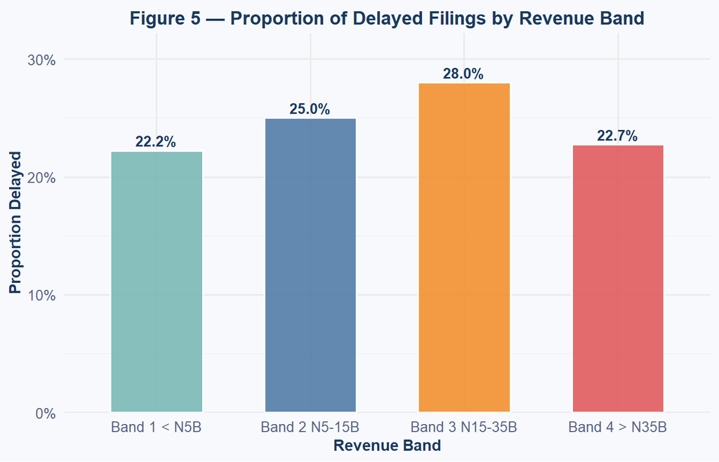

## 7. Hypothesis Testing

> **Technique 3 of 5** — ANOVA, chi-squared, post-hoc tests

### 7.1 H1: Does Filing Delay Differ Across Tax Types?

**H₀:** Mean filing delay is the same across all four tax types. **H₁:** At least one tax type has a significantly different mean filing delay.

```r
anova_model <- aov(filing_delay_days ~ tax_type, data = df)
summary(anova_model)
```

```
             Df Sum Sq Mean Sq F value  Pr(>F)
tax_type      3 100954   33651   5.387 0.00177 **
Residuals   100 624689    6247
---
Signif. codes:  0 '***' 0.001 '**' 0.01 '*' 0.05 '.' 0.1 ' ' 1
```

```r
kruskal.test(filing_delay_days ~ tax_type, data = df)
```

```
    Kruskal-Wallis rank sum test

data:  filing_delay_days by tax_type
Kruskal-Wallis chi-squared = 16.337, df = 3, p-value = 0.0009672
```

Table 7 — Dunn Post-Hoc Pairwise Comparisons

| group1 | group2 | statistic | p.adj | p.adj.signif |
| --- | --- | --- | --- | --- |
| VAT | PAYE | 3.5158 | 0.0026 | ** |
| VAT | WHT | 1.4178 | 0.1875 | ns |
| VAT | CIT | 3.2407 | 0.0036 | ** |
| PAYE | WHT | -2.0980 | 0.0718 | ns |
| PAYE | CIT | -0.2751 | 0.7832 | ns |
| WHT | CIT | 1.8229 | 0.1025 | ns |

### 7.2 H2: Is Management Type Associated with Compliance Status?

**H₀:** No association between management type and compliance status. **H₁:** Management type and compliance status are associated.

```r
ct <- table(df$management_type, df$compliance_status)
print(ct)
```

```
          On Time Delayed
  Local        55      18
  Foreign      23       8
```

```r
chi_result <- chisq.test(ct)
print(chi_result)
```

```
    Pearson's Chi-squared test with Yates' continuity correction

data:  ct
X-squared = 0, df = 1, p-value = 1
```

```r
cramers_v <- sqrt(chi_result$statistic / (sum(ct) * (min(dim(ct)) - 1)))
cat("\nCramer's V:", round(cramers_v, 4), "— negligible effect\n")
```

```
Cramer's V: 0 — negligible effect
```

**TipResult — Hypothesis 2**

The chi-squared test fails to reject H₀ (p > 0.05). Management type is **not** significantly associated with compliance status. Tax type is a far stronger differentiator than ownership structure.

## 8. Correlation Analysis

> **Technique 4 of 5** — Pearson, Spearman; correlation vs causation

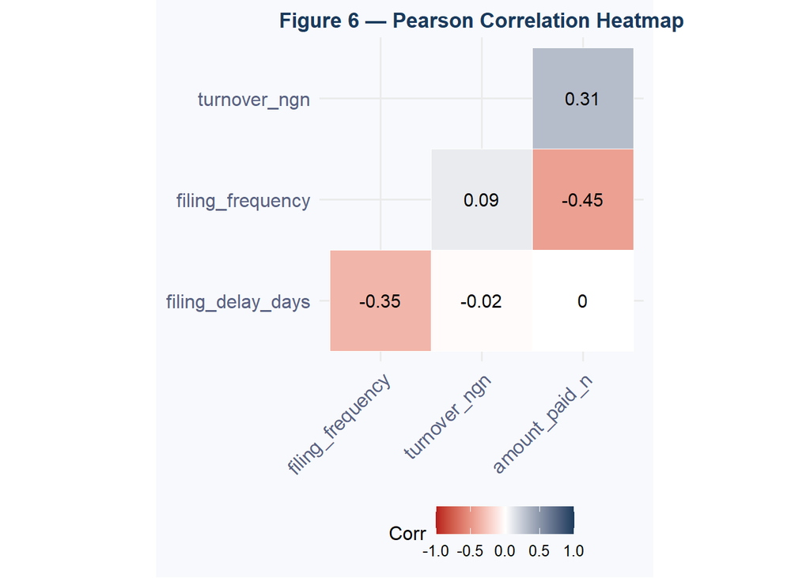

Table 8 — Spearman Correlations with Filing Delay

| Predictor | Spearman r |
| --- | --- |
| filing_frequency | -0.1401 |
| turnover_ngn | 0.1105 |
| amount_paid_n | 0.0650 |

## 9. Regression Analysis

> **Technique 5 of 5** — OLS regression with diagnostics

Table 9 — OLS Regression Coefficients

| term | estimate | std.error | statistic | p.value | conf.low | conf.high | significant |
| --- | --- | --- | --- | --- | --- | --- | --- |
| (Intercept) | -10.0095 | 89.4891 | -0.1119 | 0.9112 | -188.2424 | 168.2234 | No |
| tax_typePAYE | -1.0271 | 45.9989 | -0.0223 | 0.9822 | -92.6417 | 90.5876 | No |
| tax_typeWHT | -0.8837 | 46.0032 | -0.0192 | 0.9847 | -92.5070 | 90.7396 | No |
| tax_typeCIT | 93.6902 | 46.5435 | 2.0130 | 0.0477 | 0.9908 | 186.3897 | Yes |
| management_typeForeign | 6.2296 | 97.3037 | 0.0640 | 0.9491 | -187.5675 | 200.0267 | No |
| industry_sectorOil and Gas | 5.4404 | 99.5133 | 0.0547 | 0.9565 | -192.7575 | 203.6383 | No |
| turnover_ngn | 0.0000 | 0.0000 | 0.8596 | 0.3927 | 0.0000 | 0.0000 | No |
| amount_paid_n | 0.0000 | 0.0000 | -1.9017 | 0.0610 | 0.0000 | 0.0000 | No |

Table 10 — Model Fit Statistics

| r.squared | adj.r.squared | sigma | statistic | p.value |
| --- | --- | --- | --- | --- |
| 0.166 | 0.0891 | 88.5442 | 2.1602 | 0.0472 |

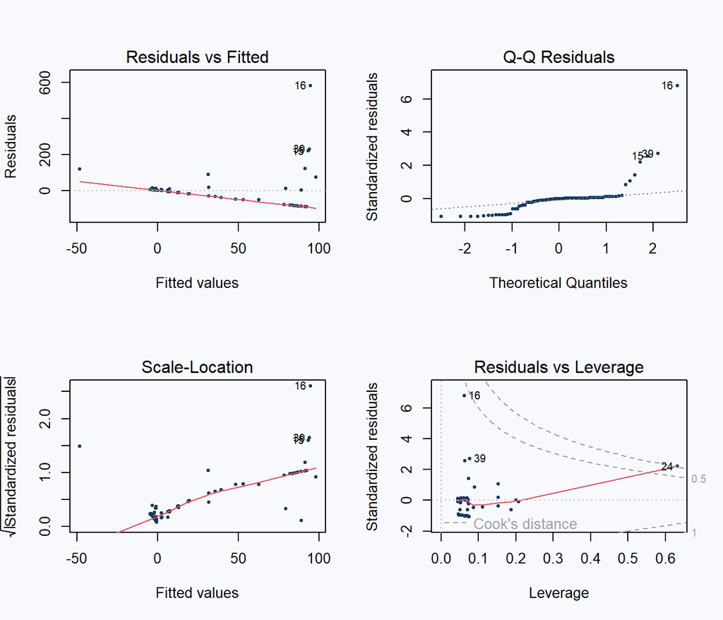

Table 11 — Variance Inflation Factors

|  | Predictor | VIF |
| --- | --- | --- |
| tax_type | tax_type | 1.842 |
| management_type | management_type | 22.931 |
| industry_sector | industry_sector | 24.360 |
| turnover_ngn | turnover_ngn | 1.325 |
| amount_paid_n | amount_paid_n | 1.517 |

## 10. Integrated Findings

**ImportantSingle Integrated Finding**

Filing compliance failure in this dataset is a concentrated, obligation-type-specific problem centred on CIT. It persists independently of company size, management structure, and industry sector.

**Recommendation:** Implement a tiered, obligation-specific monitoring protocol — placing CIT on a dedicated 90/60/30-day pre-deadline alert schedule, introducing monthly estimated CIT payments modelled on upstream oil and gas practice, and applying lighter-touch monthly monitoring for VAT and PAYE.

## 11. Limitations & Further Work

**Warning**

**Sample scope:** 104 observations across 13 clients within a single advisory portfolio, not a random sample of Nigerian taxpayers.

**Cross-sectional structure:** Each client contributes multiple filings; standard errors may be understated. A mixed-effects model would be more appropriate.

**Zero-inflation:** Severe zero-inflation violates OLS assumptions. A hurdle model combining logistic regression with truncated regression would be more suitable.

**Filing_Frequency collinearity:** Perfectly collinear with Tax_Type (CIT is the only annual filer) and was not included as an independent predictor.

**With more data, time, or computing power:** extend the panel to additional years for fixed-effects regression; apply a zero-inflated negative binomial model; incorporate FIRS penalty data; build a machine-learning classifier to predict next-period non-compliance.

## References

Adi, B. (2026). *AI-powered business analytics: A practical textbook for data-driven decision making.* Lagos Business School / markanalytics.online. https://markanalytics.online

R Core Team. (2024). *R: A language and environment for statistical computing.* R Foundation for Statistical Computing. https://www.R-project.org/

Wickham, H., et al. (2019). Welcome to the tidyverse. *Journal of Open Source Software, 4*(43), 1686. https://doi.org/10.21105/joss.01686

Wickham, H. (2016). *ggplot2: Elegant graphics for data analysis.* Springer.

Obadan, L. (2026). *Corporate tax compliance filing records — anonymised client dataset* [Dataset]. Compiled from operational compliance tracking registers, Lagos, Nigeria, January 2024 to July 2025. Data available on request from the author.

## Appendix: AI Usage Statement

Claude (Anthropic) was used to assist with structuring the Quarto document, generating initial R code scaffolding, and suggesting appropriate diagnostic approaches. All analytical decisions — selection of the outcome variable, choice of statistical tests, interpretation of coefficients, and the integrated recommendation — were made independently by the author. The dataset was compiled from records within my own professional practice, and no data was shared with any AI tool at any stage.